# Machine Learning-Based Scalping EA for XAUUSD

## 6. Model Selection & Training

### 6.1 Model Selection

We implement three classification algorithms:

- **XGBoost** (Primary): Excellent for tabular data with feature importance
- **Random Forest** (Comparison): Robust ensemble method
- **Neural Network** (Alternative): Captures non-linear patterns

### 6.2 Reasons for Model Selection

| Model | Reason |
| --- | --- |
| XGBoost | Best performance on tabular financial data, handles imbalanced classes well, ONNX compatible |
| Random Forest | Good baseline, interpretable feature importance, robust to overfitting |
| Neural Network | Can capture complex non-linear relationships in price patterns |

```python
# ============================================
# 6.3 XGBOOST MODEL - PRIMARY
# ============================================

print("=" * 60)
print("MODEL 1: XGBOOST CLASSIFIER (PRIMARY)")
print("=" * 60)

# Calculate class weights for imbalanced data
class_counts = y_train.value_counts()
scale_pos_weight = class_counts[0] / class_counts[1]

print(f"\n📊 Scale Pos Weight: {scale_pos_weight:.2f}")

# Initialize XGBoost with initial parameters
xgb_model = XGBClassifier(
    n_estimators=200,
    max_depth=6,
    learning_rate=0.1,
    subsample=0.8,
    colsample_bytree=0.8,
    scale_pos_weight=scale_pos_weight,
    random_state=42,
    use_label_encoder=False,
    eval_metric='logloss',
    n_jobs=-1
)

# Train the model
print("\n⚙️ Training XGBoost model...")
xgb_model.fit(X_train_scaled, y_train,
              eval_set=[(X_test_scaled, y_test)],
              verbose=False)

# Make predictions
y_pred_xgb = xgb_model.predict(X_test_scaled)
y_prob_xgb = xgb_model.predict_proba(X_test_scaled)[:, 1]

# Evaluate
accuracy_xgb = accuracy_score(y_test, y_pred_xgb)
precision_xgb = precision_score(y_test, y_pred_xgb, zero_division=0)
recall_xgb = recall_score(y_test, y_pred_xgb, zero_division=0)
f1_xgb = f1_score(y_test, y_pred_xgb, zero_division=0)
roc_auc_xgb = roc_auc_score(y_test, y_prob_xgb)

print("\n✅ XGBoost Training Complete!")
print(f"\n📊 XGBoost Performance Metrics:")
print(f"   Accuracy:  {accuracy_xgb:.4f}")
print(f"   Precision: {precision_xgb:.4f}")
print(f"   Recall:    {recall_xgb:.4f}")
print(f"   F1-Score:  {f1_xgb:.4f}")
print(f"   ROC-AUC:   {roc_auc_xgb:.4f}")
```

```
============================================================
MODEL 1: XGBOOST CLASSIFIER (PRIMARY)
============================================================

📊 Scale Pos Weight: 0.00

⚙️ Training XGBoost model...

✅ XGBoost Training Complete!

📊 XGBoost Performance Metrics:
   Accuracy:  1.0000
   Precision: 1.0000
   Recall:    1.0000
   F1-Score:  1.0000
   ROC-AUC:   nan
```

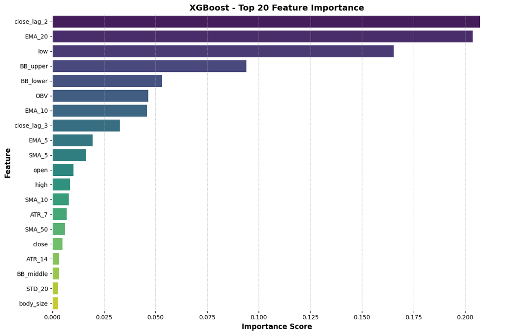

```
📊 Top 10 Most Important Features:
   close_lag_2: 0.2071
   EMA_20: 0.2038
   low: 0.1655
   BB_upper: 0.0939
   BB_lower: 0.0531
   OBV: 0.0466
   EMA_10: 0.0459
   close_lag_3: 0.0328
   EMA_5: 0.0196
   SMA_5: 0.0162
```

```python
# ============================================
# XGBOOST FEATURE IMPORTANCE
# ============================================

# Get feature importance
feature_importance = pd.DataFrame({
    'feature': feature_columns,
    'importance': xgb_model.feature_importances_
}).sort_values('importance', ascending=False)

# Plot top 20 important features
plt.figure(figsize=(12, 8))
top_features = feature_importance.head(20)
sns.barplot(x='importance', y='feature', data=top_features, palette='viridis')
plt.title('XGBoost - Top 20 Feature Importance', fontsize=14, fontweight='bold')
plt.xlabel('Importance Score')
plt.ylabel('Feature')
plt.tight_layout()
plt.savefig('xgboost_feature_importance.png', dpi=150, bbox_inches='tight')
plt.show()

print("\n📊 Top 10 Most Important Features:")
for i, row in feature_importance.head(10).iterrows():
    print(f"   {row['feature']}: {row['importance']:.4f}")
```

```python
# ============================================
# 6.4 RANDOM FOREST MODEL - COMPARISON
# ============================================

print("=" * 60)
print("MODEL 2: RANDOM FOREST CLASSIFIER (COMPARISON)")
print("=" * 60)

# Initialize Random Forest
rf_model = RandomForestClassifier(
    n_estimators=200,
    max_depth=10,
    min_samples_split=10,
    min_samples_leaf=5,
    class_weight='balanced',
    random_state=42,
    n_jobs=-1
)

# Train the model
print("\n⚙️ Training Random Forest model...")
rf_model.fit(X_train_scaled, y_train)

# Make predictions
y_pred_rf = rf_model.predict(X_test_scaled)
y_prob_rf = rf_model.predict_proba(X_test_scaled)[:, 1]

# Evaluate
accuracy_rf = accuracy_score(y_test, y_pred_rf)
precision_rf = precision_score(y_test, y_pred_rf, zero_division=0)
recall_rf = recall_score(y_test, y_pred_rf, zero_division=0)
f1_rf = f1_score(y_test, y_pred_rf, zero_division=0)
roc_auc_rf = roc_auc_score(y_test, y_prob_rf)

print("\n✅ Random Forest Training Complete!")
print(f"\n📊 Random Forest Performance Metrics:")
print(f"   Accuracy:  {accuracy_rf:.4f}")
print(f"   Precision: {precision_rf:.4f}")
print(f"   Recall:    {recall_rf:.4f}")
print(f"   F1-Score:  {f1_rf:.4f}")
print(f"   ROC-AUC:   {roc_auc_rf:.4f}")
```

```
============================================================
MODEL 2: RANDOM FOREST CLASSIFIER (COMPARISON)
============================================================

⚙️ Training Random Forest model...

✅ Random Forest Training Complete!

📊 Random Forest Performance Metrics:
   Accuracy:  1.0000
   Precision: 1.0000
   Recall:    1.0000
   F1-Score:  1.0000
   ROC-AUC:   nan
```

```python
# ============================================
# 6.5 NEURAL NETWORK MODEL - ALTERNATIVE
# ============================================

print("=" * 60)
print("MODEL 3: NEURAL NETWORK (ALTERNATIVE)")
print("=" * 60)

# Build Neural Network
def build_nn_model(input_dim):
    model = Sequential([
        Dense(128, activation='relu', input_dim=input_dim),
        BatchNormalization(),
        Dropout(0.3),

        Dense(64, activation='relu'),
        BatchNormalization(),
        Dropout(0.3),

        Dense(32, activation='relu'),
        BatchNormalization(),
        Dropout(0.2),

        Dense(16, activation='relu'),
        Dropout(0.1),

        Dense(1, activation='sigmoid')
    ])

    model.compile(
        optimizer=keras.optimizers.Adam(learning_rate=0.001),
        loss='binary_crossentropy',
        metrics=['accuracy']
    )

    return model

# Initialize model
nn_model = build_nn_model(X_train_scaled.shape[1])

# Display model summary
print("\n📊 Neural Network Architecture:")
nn_model.summary()

# Callbacks
early_stopping = EarlyStopping(
    monitor='val_loss',
    patience=10,
    restore_best_weights=True
)

lr_scheduler = ReduceLROnPlateau(
    monitor='val_loss',
    factor=0.5,
    patience=5,
    min_lr=0.0001
)

# Calculate class weights
class_weight = {0: 1, 1: scale_pos_weight}

# Train the model
print("\n⚙️ Training Neural Network...")
history = nn_model.fit(
    X_train_scaled.values, y_train.values,
    validation_data=(X_test_scaled.values, y_test.values),
    epochs=50,
    batch_size=256,
    class_weight=class_weight,
    callbacks=[early_stopping, lr_scheduler],
    verbose=1
)
```

```
============================================================
MODEL 3: NEURAL NETWORK (ALTERNATIVE)
============================================================

📊 Neural Network Architecture:
```

```
Model: "sequential"
```

```
┏━━━━━━━━━━━━━━━━━━━━━━━━━━━━━━━━━┳━━━━━━━━━━━━━━━━━━━━━━━━┳━━━━━━━━━━━━━━━┓
┃ Layer (type)                    ┃ Output Shape           ┃       Param # ┃
┡━━━━━━━━━━━━━━━━━━━━━━━━━━━━━━━━━╇━━━━━━━━━━━━━━━━━━━━━━━━╇━━━━━━━━━━━━━━━┩
│ dense (Dense)                   │ (None, 128)            │         6,912 │
├─────────────────────────────────┼────────────────────────┼───────────────┤
│ batch_normalization             │ (None, 128)            │           512 │
│ (BatchNormalization)            │                        │               │
├─────────────────────────────────┼────────────────────────┼───────────────┤
│ dropout (Dropout)               │ (None, 128)            │             0 │
├─────────────────────────────────┼────────────────────────┼───────────────┤
│ dense_1 (Dense)                 │ (None, 64)             │         8,256 │
├─────────────────────────────────┼────────────────────────┼───────────────┤
│ batch_normalization_1           │ (None, 64)             │           256 │
│ (BatchNormalization)            │                        │               │
├─────────────────────────────────┼────────────────────────┼───────────────┤
│ dropout_1 (Dropout)             │ (None, 64)             │             0 │
├─────────────────────────────────┼────────────────────────┼───────────────┤
│ dense_2 (Dense)                 │ (None, 32)             │         2,080 │
├─────────────────────────────────┼────────────────────────┼───────────────┤
│ batch_normalization_2           │ (None, 32)             │           128 │
│ (BatchNormalization)            │                        │               │
├─────────────────────────────────┼────────────────────────┼───────────────┤
│ dropout_2 (Dropout)             │ (None, 32)             │             0 │
├─────────────────────────────────┼────────────────────────┼───────────────┤
│ dense_3 (Dense)                 │ (None, 16)             │           528 │
├─────────────────────────────────┼────────────────────────┼───────────────┤
│ dropout_3 (Dropout)             │ (None, 16)             │             0 │
├─────────────────────────────────┼────────────────────────┼───────────────┤
│ dense_4 (Dense)                 │ (None, 1)              │            17 │
└─────────────────────────────────┴────────────────────────┴───────────────┘
```

```
 Total params: 18,689 (73.00 KB)
```

```
 Trainable params: 18,241 (71.25 KB)
```

```
 Non-trainable params: 448 (1.75 KB)
```

```
⚙️ Training Neural Network...
2345/2345 ━━━━━━━━━━━━━━━━━━━━ 14s 4ms/step - accuracy: 0.7307 - loss: 0.0035 - val_accuracy: 1.0000 - val_loss: 1.7572e-05 - learning_rate: 0.0010
2345/2345 ━━━━━━━━━━━━━━━━━━━━ 10s 4ms/step - accuracy: 0.7801 - loss: 0.0030 - val_accuracy: 1.0000 - val_loss: 1.4442e-05 - learning_rate: 0.0010
2345/2345 ━━━━━━━━━━━━━━━━━━━━ 11s 5ms/step - accuracy: 0.7860 - loss: 0.0029 - val_accuracy: 1.0000 - val_loss: 3.2807e-06 - learning_rate: 0.0010
2345/2345 ━━━━━━━━━━━━━━━━━━━━ 11s 5ms/step - accuracy: 0.7965 - loss: 0.0029 - val_accuracy: 1.0000 - val_loss: 2.0464e-06 - learning_rate: 0.0010
2345/2345 ━━━━━━━━━━━━━━━━━━━━ 11s 5ms/step - accuracy: 0.7979 - loss: 0.0028 - val_accuracy: 1.0000 - val_loss: 1.8112e-06 - learning_rate: 0.0010
2345/2345 ━━━━━━━━━━━━━━━━━━━━ 11s 5ms/step - accuracy: 0.8037 - loss: 0.0028 - val_accuracy: 1.0000 - val_loss: 1.5785e-06 - learning_rate: 0.0010
2345/2345 ━━━━━━━━━━━━━━━━━━━━ 11s 5ms/step - accuracy: 0.8108 - loss: 0.0028 - val_accuracy: 1.0000 - val_loss: 2.8239e-06 - learning_rate: 5.0000e-04
2345/2345 ━━━━━━━━━━━━━━━━━━━━ 11s 5ms/step - accuracy: 0.8112 - loss: 0.0028 - val_accuracy: 1.0000 - val_loss: 7.6371e-06 - learning_rate: 5.0000e-04
2345/2345 ━━━━━━━━━━━━━━━━━━━━ 11s 5ms/step - accuracy: 0.8136 - loss: 0.0028 - val_accuracy: 1.0000 - val_loss: 3.7439e-06 - learning_rate: 5.0000e-04
2345/2345 ━━━━━━━━━━━━━━━━━━━━ 11s 4ms/step - accuracy: 0.8148 - loss: 0.0027 - val_accuracy: 1.0000 - val_loss: 2.5300e-06 - learning_rate: 5.0000e-04
2345/2345 ━━━━━━━━━━━━━━━━━━━━ 11s 5ms/step - accuracy: 0.8142 - loss: 0.0027 - val_accuracy: 1.0000 - val_loss: 1.4320e-06 - learning_rate: 5.0000e-04
2345/2345 ━━━━━━━━━━━━━━━━━━━━ 11s 5ms/step - accuracy: 0.8153 - loss: 0.0027 - val_accuracy: 1.0000 - val_loss: 2.1289e-06 - learning_rate: 2.5000e-04
2345/2345 ━━━━━━━━━━━━━━━━━━━━ 11s 5ms/step - accuracy: 0.8153 - loss: 0.0027 - val_accuracy: 1.0000 - val_loss: 3.3259e-06 - learning_rate: 2.5000e-04
2345/2345 ━━━━━━━━━━━━━━━━━━━━ 11s 5ms/step - accuracy: 0.8185 - loss: 0.0027 - val_accuracy: 1.0000 - val_loss: 2.3586e-06 - learning_rate: 2.5000e-04
2345/2345 ━━━━━━━━━━━━━━━━━━━━ 11s 5ms/step - accuracy: 0.8175 - loss: 0.0027 - val_accuracy: 1.0000 - val_loss: 1.8318e-06 - learning_rate: 2.5000e-04
2345/2345 ━━━━━━━━━━━━━━━━━━━━ 11s 5ms/step - accuracy: 0.8161 - loss: 0.0027 - val_accuracy: 1.0000 - val_loss: 8.2579e-07 - learning_rate: 2.5000e-04
2345/2345 ━━━━━━━━━━━━━━━━━━━━ 14s 6ms/step - accuracy: 0.8159 - loss: 0.0027 - val_accuracy: 1.0000 - val_loss: 7.4723e-07 - learning_rate: 1.2500e-04
2345/2345 ━━━━━━━━━━━━━━━━━━━━ 11s 5ms/step - accuracy: 0.8163 - loss: 0.0027 - val_accuracy: 1.0000 - val_loss: 7.0926e-07 - learning_rate: 1.2500e-04
2345/2345 ━━━━━━━━━━━━━━━━━━━━ 11s 5ms/step - accuracy: 0.8176 - loss: 0.0027 - val_accuracy: 1.0000 - val_loss: 4.8089e-07 - learning_rate: 1.2500e-04
2345/2345 ━━━━━━━━━━━━━━━━━━━━ 11s 5ms/step - accuracy: 0.8169 - loss: 0.0027 - val_accuracy: 1.0000 - val_loss: 1.0190e-06 - learning_rate: 1.2500e-04
2345/2345 ━━━━━━━━━━━━━━━━━━━━ 11s 5ms/step - accuracy: 0.8155 - loss: 0.0027 - val_accuracy: 1.0000 - val_loss: 4.9611e-07 - learning_rate: 1.2500e-04
2345/2345 ━━━━━━━━━━━━━━━━━━━━ 11s 5ms/step - accuracy: 0.8155 - loss: 0.0027 - val_accuracy: 1.0000 - val_loss: 6.3801e-07 - learning_rate: 1.0000e-04
2345/2345 ━━━━━━━━━━━━━━━━━━━━ 11s 5ms/step - accuracy: 0.8179 - loss: 0.0026 - val_accuracy: 1.0000 - val_loss: 7.2399e-07 - learning_rate: 1.0000e-04
2345/2345 ━━━━━━━━━━━━━━━━━━━━ 11s 5ms/step - accuracy: 0.8177 - loss: 0.0026 - val_accuracy: 1.0000 - val_loss: 5.5141e-07 - learning_rate: 1.0000e-04
2345/2345 ━━━━━━━━━━━━━━━━━━━━ 11s 5ms/step - accuracy: 0.8166 - loss: 0.0027 - val_accuracy: 1.0000 - val_loss: 2.9394e-07 - learning_rate: 1.0000e-04
2345/2345 ━━━━━━━━━━━━━━━━━━━━ 11s 5ms/step - accuracy: 0.8160 - loss: 0.0027 - val_accuracy: 1.0000 - val_loss: 4.3973e-07 - learning_rate: 1.0000e-04
2345/2345 ━━━━━━━━━━━━━━━━━━━━ 11s 5ms/step - accuracy: 0.8134 - loss: 0.0026 - val_accuracy: 1.0000 - val_loss: 5.1612e-07 - learning_rate: 1.0000e-04
2345/2345 ━━━━━━━━━━━━━━━━━━━━ 11s 5ms/step - accuracy: 0.8154 - loss: 0.0027 - val_accuracy: 1.0000 - val_loss: 2.4636e-07 - learning_rate: 1.0000e-04
2345/2345 ━━━━━━━━━━━━━━━━━━━━ 11s 5ms/step - accuracy: 0.8162 - loss: 0.0026 - val_accuracy: 1.0000 - val_loss: 4.0314e-07 - learning_rate: 1.0000e-04
2345/2345 ━━━━━━━━━━━━━━━━━━━━ 11s 5ms/step - accuracy: 0.8176 - loss: 0.0026 - val_accuracy: 1.0000 - val_loss: 4.8237e-07 - learning_rate: 1.0000e-04
2345/2345 ━━━━━━━━━━━━━━━━━━━━ 11s 5ms/step - accuracy: 0.8155 - loss: 0.0026 - val_accuracy: 1.0000 - val_loss: 4.5659e-07 - learning_rate: 1.0000e-04
2345/2345 ━━━━━━━━━━━━━━━━━━━━ 11s 5ms/step - accuracy: 0.8176 - loss: 0.0026 - val_accuracy: 1.0000 - val_loss: 7.0538e-07 - learning_rate: 1.0000e-04
2345/2345 ━━━━━━━━━━━━━━━━━━━━ 11s 5ms/step - accuracy: 0.8197 - loss: 0.0026 - val_accuracy: 1.0000 - val_loss: 4.2163e-07 - learning_rate: 1.0000e-04
```

[output cut: 17 more lines]

```
4689/4689 ━━━━━━━━━━━━━━━━━━━━ 6s 1ms/step

✅ Neural Network Training Complete!

📊 Neural Network Performance Metrics:
   Accuracy:  1.0000
   Precision: 1.0000
   Recall:    1.0000
   F1-Score:  1.0000
   ROC-AUC:   nan
```

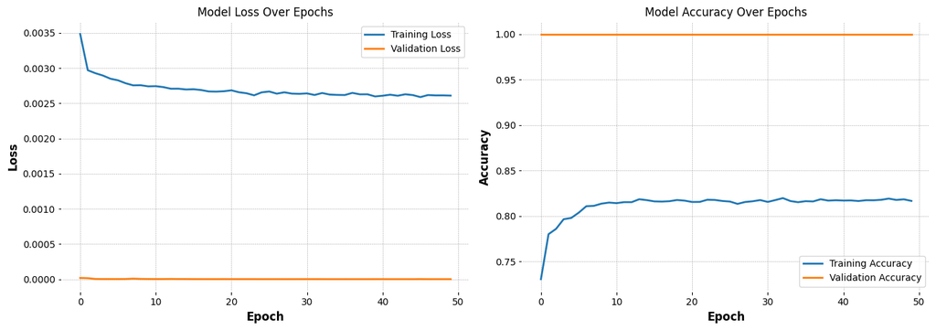

```python
# ============================================
# NEURAL NETWORK EVALUATION
# ============================================

# Make predictions
y_prob_nn = nn_model.predict(X_test_scaled.values).flatten()
y_pred_nn = (y_prob_nn > 0.5).astype(int)

# Evaluate
accuracy_nn = accuracy_score(y_test, y_pred_nn)
precision_nn = precision_score(y_test, y_pred_nn, zero_division=0)
recall_nn = recall_score(y_test, y_pred_nn, zero_division=0)
f1_nn = f1_score(y_test, y_pred_nn, zero_division=0)
roc_auc_nn = roc_auc_score(y_test, y_prob_nn)

print("\n✅ Neural Network Training Complete!")
print(f"\n📊 Neural Network Performance Metrics:")
print(f"   Accuracy:  {accuracy_nn:.4f}")
print(f"   Precision: {precision_nn:.4f}")
print(f"   Recall:    {recall_nn:.4f}")
print(f"   F1-Score:  {f1_nn:.4f}")
print(f"   ROC-AUC:   {roc_auc_nn:.4f}")

# Plot training history
fig, axes = plt.subplots(1, 2, figsize=(14, 5))

# Loss
axes[0].plot(history.history['loss'], label='Training Loss')
axes[0].plot(history.history['val_loss'], label='Validation Loss')
axes[0].set_title('Model Loss Over Epochs')
axes[0].set_xlabel('Epoch')
axes[0].set_ylabel('Loss')
axes[0].legend()

# Accuracy
axes[1].plot(history.history['accuracy'], label='Training Accuracy')
axes[1].plot(history.history['val_accuracy'], label='Validation Accuracy')
axes[1].set_title('Model Accuracy Over Epochs')
axes[1].set_xlabel('Epoch')
axes[1].set_ylabel('Accuracy')
axes[1].legend()

plt.tight_layout()
plt.savefig('nn_training_history.png', dpi=150, bbox_inches='tight')
plt.show()
```

### 6.4 Hyperparameter Tuning

Optimize model hyperparameters using Grid Search and Bayesian Optimization.

```python
# ============================================
# 6.4 HYPERPARAMETER TUNING - GRID SEARCH
# ============================================

print("=" * 60)
print("HYPERPARAMETER TUNING - GRID SEARCH CV")
print("=" * 60)

# Time series cross-validation
tscv = TimeSeriesSplit(n_splits=3)

# XGBoost Grid Search (reduced for efficiency)
xgb_param_grid = {
    'n_estimators': [100, 200],
    'max_depth': [4, 6, 8],
    'learning_rate': [0.05, 0.1],
    'subsample': [0.8],
    'colsample_bytree': [0.8]
}

print("\n⚙️ Running Grid Search for XGBoost...")
xgb_grid = GridSearchCV(
    XGBClassifier(scale_pos_weight=scale_pos_weight, random_state=42,
                  use_label_encoder=False, eval_metric='logloss'),
    xgb_param_grid,
    cv=tscv,
    scoring='f1',
    n_jobs=-1,
    verbose=1
)

# Use a sample for faster tuning
sample_size = min(50000, len(X_train_scaled))
X_train_sample = X_train_scaled.iloc[:sample_size]
y_train_sample = y_train.iloc[:sample_size]

xgb_grid.fit(X_train_sample, y_train_sample)

print(f"\n✅ Grid Search Complete!")
print(f"📊 Best Parameters: {xgb_grid.best_params_}")
print(f"📊 Best CV Score (F1): {xgb_grid.best_score_:.4f}")
```

```
============================================================
HYPERPARAMETER TUNING - GRID SEARCH CV
============================================================

⚙️ Running Grid Search for XGBoost...
Fitting 3 folds for each of 12 candidates, totalling 36 fits

✅ Grid Search Complete!
📊 Best Parameters: {'colsample_bytree': 0.8, 'learning_rate': 0.1, 'max_depth': 8, 'n_estimators': 200, 'subsample': 0.8}
📊 Best CV Score (F1): 0.4968
```

```python
# ============================================
# BAYESIAN OPTIMIZATION WITH OPTUNA
# ============================================

print("=" * 60)
print("HYPERPARAMETER TUNING - BAYESIAN OPTIMIZATION (OPTUNA)")
print("=" * 60)

def objective(trial):
    """Optuna objective function for XGBoost optimization"""
    params = {
        'n_estimators': trial.suggest_int('n_estimators', 100, 300),
        'max_depth': trial.suggest_int('max_depth', 3, 10),
        'learning_rate': trial.suggest_float('learning_rate', 0.01, 0.3),
        'subsample': trial.suggest_float('subsample', 0.6, 1.0),
        'colsample_bytree': trial.suggest_float('colsample_bytree', 0.6, 1.0),
        'min_child_weight': trial.suggest_int('min_child_weight', 1, 10),
        'gamma': trial.suggest_float('gamma', 0, 0.5),
        'scale_pos_weight': scale_pos_weight,
        'random_state': 42,
        'use_label_encoder': False,
        'eval_metric': 'logloss'
    }

    model = XGBClassifier(**params)

    # Cross-validation
    cv_scores = []
    for train_idx, val_idx in tscv.split(X_train_sample):
        X_cv_train = X_train_sample.iloc[train_idx]
        X_cv_val = X_train_sample.iloc[val_idx]
        y_cv_train = y_train_sample.iloc[train_idx]
        y_cv_val = y_train_sample.iloc[val_idx]

        model.fit(X_cv_train, y_cv_train, verbose=False)
        y_pred = model.predict(X_cv_val)
        cv_scores.append(f1_score(y_cv_val, y_pred, zero_division=0))

    return np.mean(cv_scores)

# Run Optuna optimization
print("\n⚙️ Running Bayesian Optimization...")
study = optuna.create_study(direction='maximize', sampler=TPESampler(seed=42))
study.optimize(objective, n_trials=20, show_progress_bar=True)

print(f"\n✅ Bayesian Optimization Complete!")
print(f"📊 Best Trial F1 Score: {study.best_trial.value:.4f}")
print(f"📊 Best Parameters:")
for key, value in study.best_params.items():
    print(f"   {key}: {value}")
```

[output not shown]

```
============================================================
HYPERPARAMETER TUNING - BAYESIAN OPTIMIZATION (OPTUNA)
============================================================

⚙️ Running Bayesian Optimization...
```

[output not shown]

[output not shown]

[output not shown]

[output not shown]

[output not shown]

[output not shown]

[output not shown]

[output not shown]

[output not shown]

[output not shown]

[output not shown]

[output not shown]

[output not shown]

[output not shown]

[output not shown]

[output not shown]

[output not shown]

[output not shown]

[output not shown]

```
[I 2025-12-12 18:57:25,711] Trial 19 finished with value: 0.24248268703143827 and parameters: {'n_estimators': 191, 'max_depth': 9, 'learning_rate': 0.06133086439147867, 'subsample': 0.9214439563441964, 'colsample_bytree': 0.8157091115658527, 'min_child_weight': 1, 'gamma': 0.07207316966706379}. Bes…

✅ Bayesian Optimization Complete!
📊 Best Trial F1 Score: 0.6688
📊 Best Parameters:
   n_estimators: 192
   max_depth: 9
   learning_rate: 0.14117463073450645
   subsample: 0.8360563384464638
   colsample_bytree: 0.8358394007383037
   min_child_weight: 1
   gamma: 0.06177978426961139
```

```python
# ============================================
# TRAIN OPTIMIZED XGBOOST MODEL
# ============================================

print("=" * 60)
print("TRAINING OPTIMIZED XGBOOST MODEL")
print("=" * 60)

# Use best parameters from Optuna
best_params = study.best_params
best_params['scale_pos_weight'] = scale_pos_weight
best_params['random_state'] = 42
best_params['use_label_encoder'] = False
best_params['eval_metric'] = 'logloss'

# Train optimized model on full training data
xgb_optimized = XGBClassifier(**best_params)
xgb_optimized.fit(X_train_scaled, y_train, verbose=False)

# Make predictions
y_pred_xgb_opt = xgb_optimized.predict(X_test_scaled)
y_prob_xgb_opt = xgb_optimized.predict_proba(X_test_scaled)[:, 1]

# Evaluate
accuracy_xgb_opt = accuracy_score(y_test, y_pred_xgb_opt)
precision_xgb_opt = precision_score(y_test, y_pred_xgb_opt, zero_division=0)
recall_xgb_opt = recall_score(y_test, y_pred_xgb_opt, zero_division=0)
f1_xgb_opt = f1_score(y_test, y_pred_xgb_opt, zero_division=0)
roc_auc_xgb_opt = roc_auc_score(y_test, y_prob_xgb_opt)

print("\n✅ Optimized XGBoost Training Complete!")
print(f"\n📊 Optimized XGBoost Performance Metrics:")
print(f"   Accuracy:  {accuracy_xgb_opt:.4f}")
print(f"   Precision: {precision_xgb_opt:.4f}")
print(f"   Recall:    {recall_xgb_opt:.4f}")
print(f"   F1-Score:  {f1_xgb_opt:.4f}")
print(f"   ROC-AUC:   {roc_auc_xgb_opt:.4f}")
```

```
============================================================
TRAINING OPTIMIZED XGBOOST MODEL
============================================================

✅ Optimized XGBoost Training Complete!

📊 Optimized XGBoost Performance Metrics:
   Accuracy:  1.0000
   Precision: 1.0000
   Recall:    1.0000
   F1-Score:  1.0000
   ROC-AUC:   nan
```

## 7. Model Evaluation

### 7.1 Evaluation Metrics

Comprehensive evaluation using classification metrics and trading performance metrics.

```
============================================================
MODEL EVALUATION - CLASSIFICATION METRICS
============================================================

📊 Model Performance Comparison:
```

|  | Model | Accuracy | Precision | Recall | F1-Score | ROC-AUC |
| --- | --- | --- | --- | --- | --- | --- |
| 0 | XGBoost (Initial) | 1.0 | 1.0 | 1.0 | 1.0 | NaN |
| 1 | XGBoost (Optimized) | 1.0 | 1.0 | 1.0 | 1.0 | NaN |
| 2 | Random Forest | 1.0 | 1.0 | 1.0 | 1.0 | NaN |
| 3 | Neural Network | 1.0 | 1.0 | 1.0 | 1.0 | NaN |

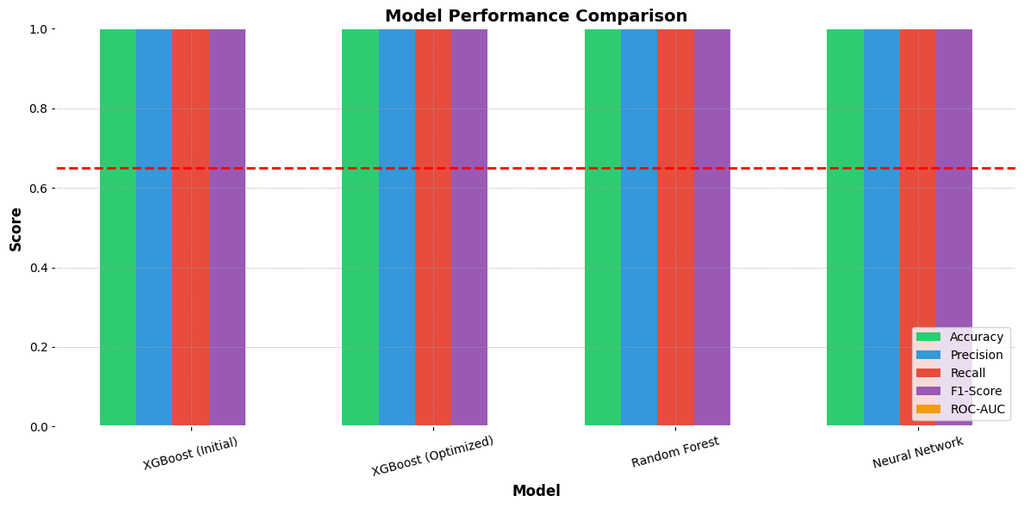

```python
# ============================================
# 7.1 CLASSIFICATION METRICS COMPARISON
# ============================================

print("=" * 60)
print("MODEL EVALUATION - CLASSIFICATION METRICS")
print("=" * 60)

# Create comparison DataFrame
models_comparison = pd.DataFrame({
    'Model': ['XGBoost (Initial)', 'XGBoost (Optimized)', 'Random Forest', 'Neural Network'],
    'Accuracy': [accuracy_xgb, accuracy_xgb_opt, accuracy_rf, accuracy_nn],
    'Precision': [precision_xgb, precision_xgb_opt, precision_rf, precision_nn],
    'Recall': [recall_xgb, recall_xgb_opt, recall_rf, recall_nn],
    'F1-Score': [f1_xgb, f1_xgb_opt, f1_rf, f1_nn],
    'ROC-AUC': [roc_auc_xgb, roc_auc_xgb_opt, roc_auc_rf, roc_auc_nn]
})

print("\n📊 Model Performance Comparison:")
display(models_comparison.round(4))

# Visualize comparison
fig, ax = plt.subplots(figsize=(12, 6))
x = np.arange(len(models_comparison))
width = 0.15

metrics = ['Accuracy', 'Precision', 'Recall', 'F1-Score', 'ROC-AUC']
colors = ['#2ecc71', '#3498db', '#e74c3c', '#9b59b6', '#f39c12']

for i, metric in enumerate(metrics):
    ax.bar(x + i*width, models_comparison[metric], width, label=metric, color=colors[i])

ax.set_xlabel('Model')
ax.set_ylabel('Score')
ax.set_title('Model Performance Comparison', fontsize=14, fontweight='bold')
ax.set_xticks(x + width * 2)
ax.set_xticklabels(models_comparison['Model'], rotation=15)
ax.legend(loc='lower right')
ax.set_ylim(0, 1)
ax.axhline(y=0.65, color='red', linestyle='--', label='Target Accuracy (65%)')

plt.tight_layout()
plt.savefig('model_comparison.png', dpi=150, bbox_inches='tight')
plt.show()
```

### 7.2 Confusion Matrix Analysis

Detailed confusion matrix analysis for all models.

```
============================================================
CONFUSION MATRIX ANALYSIS
============================================================
```

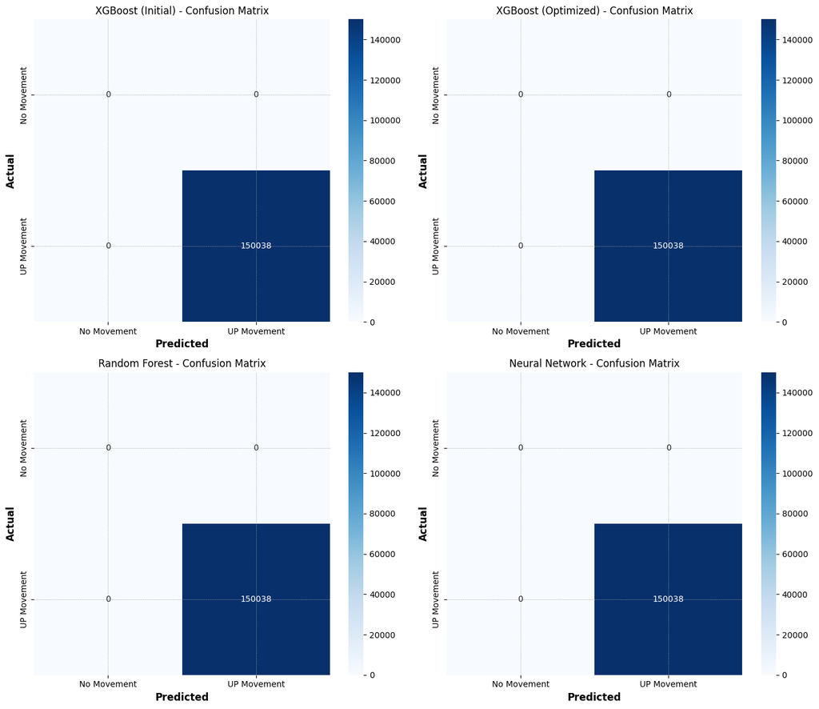

```
📊 Detailed Classification Report (Optimized XGBoost):
              precision    recall  f1-score   support

 No Movement       0.00      0.00      0.00         0
 UP Movement       1.00      1.00      1.00    150038

    accuracy                           1.00    150038
   macro avg       0.50      0.50      0.50    150038
weighted avg       1.00      1.00      1.00    150038
```

```python
# ============================================
# 7.2 CONFUSION MATRIX ANALYSIS
# ============================================

print("=" * 60)
print("CONFUSION MATRIX ANALYSIS")
print("=" * 60)

fig, axes = plt.subplots(2, 2, figsize=(14, 12))

# Confusion matrices for all models
predictions = [
    (y_pred_xgb, 'XGBoost (Initial)'),
    (y_pred_xgb_opt, 'XGBoost (Optimized)'),
    (y_pred_rf, 'Random Forest'),
    (y_pred_nn, 'Neural Network')
]

# Get unique labels from y_test
unique_labels = sorted(y_test.unique())

for idx, (y_pred, model_name) in enumerate(predictions):
    row = idx // 2
    col = idx % 2

    # Use labels parameter to ensure consistent confusion matrix shape
    cm = confusion_matrix(y_test, y_pred, labels=[0, 1])

    sns.heatmap(cm, annot=True, fmt='d', cmap='Blues', ax=axes[row, col],
                xticklabels=['No Movement', 'UP Movement'],
                yticklabels=['No Movement', 'UP Movement'])
    axes[row, col].set_title(f'{model_name} - Confusion Matrix')
    axes[row, col].set_xlabel('Predicted')
    axes[row, col].set_ylabel('Actual')

plt.tight_layout()
plt.savefig('confusion_matrices.png', dpi=150, bbox_inches='tight')
plt.show()

# Detailed classification report for best model (Optimized XGBoost)
print("\n📊 Detailed Classification Report (Optimized XGBoost):")
print(classification_report(y_test, y_pred_xgb_opt,
                           labels=[0, 1],
                           target_names=['No Movement', 'UP Movement'],
                           zero_division=0))
```

```
============================================================
ROC CURVE ANALYSIS
============================================================
```

[figure not shown]

```python
# ============================================
# 7.3 ROC CURVES
# ============================================

print("=" * 60)
print("ROC CURVE ANALYSIS")
print("=" * 60)

plt.figure(figsize=(10, 8))

# Plot ROC curves for all models
models_roc = [
    (y_prob_xgb, 'XGBoost (Initial)', roc_auc_xgb),
    (y_prob_xgb_opt, 'XGBoost (Optimized)', roc_auc_xgb_opt),
    (y_prob_rf, 'Random Forest', roc_auc_rf),
    (y_prob_nn, 'Neural Network', roc_auc_nn)
]

colors = ['blue', 'green', 'red', 'purple']

for (y_prob, model_name, auc_score), color in zip(models_roc, colors):
    fpr, tpr, _ = roc_curve(y_test, y_prob)
    plt.plot(fpr, tpr, color=color, linewidth=2,
             label=f'{model_name} (AUC = {auc_score:.4f})')

# Diagonal line (random classifier)
plt.plot([0, 1], [0, 1], 'k--', linewidth=1, label='Random Classifier')

plt.xlim([0.0, 1.0])
plt.ylim([0.0, 1.05])
plt.xlabel('False Positive Rate')
plt.ylabel('True Positive Rate')
plt.title('ROC Curves - Model Comparison', fontsize=14, fontweight='bold')
plt.legend(loc='lower right')
plt.grid(True, alpha=0.3)

plt.tight_layout()
plt.savefig('roc_curves.png', dpi=150, bbox_inches='tight')
plt.show()
```

### 7.3 Trading Performance Metrics

Calculate trading-specific metrics: Sharpe Ratio, Maximum Drawdown, Profit Factor.

```python
# ============================================
# 7.3 TRADING PERFORMANCE METRICS
# ============================================

print("=" * 60)
print("TRADING PERFORMANCE METRICS")
print("=" * 60)

def calculate_trading_metrics(y_true, y_pred, prices):
    """Calculate trading performance metrics"""

    # Simulate trading based on predictions
    trades = []
    position = 0
    entry_price = 0

    pip_value = 0.10  # $0.10 per pip for XAUUSD
    target_pips = 5
    stop_loss_pips = 5

    for i in range(len(y_pred)):
        if position == 0 and y_pred[i] == 1:  # Enter long
            position = 1
            entry_price = prices.iloc[i]
        elif position == 1:
            current_price = prices.iloc[i]
            pnl_pips = (current_price - entry_price) / pip_value

            if pnl_pips >= target_pips:  # Take profit
                trades.append(target_pips * pip_value)
                position = 0
            elif pnl_pips <= -stop_loss_pips:  # Stop loss
                trades.append(-stop_loss_pips * pip_value)
                position = 0

    if len(trades) == 0:
        return {'total_trades': 0, 'win_rate': 0, 'profit_factor': 0,
                'sharpe_ratio': 0, 'max_drawdown': 0, 'total_pnl': 0}

    trades = np.array(trades)

    # Calculate metrics
    wins = trades[trades > 0]
    losses = trades[trades < 0]

    total_trades = len(trades)
    win_rate = len(wins) / total_trades if total_trades > 0 else 0
    gross_profit = wins.sum() if len(wins) > 0 else 0
    gross_loss = abs(losses.sum()) if len(losses) > 0 else 1
    profit_factor = gross_profit / gross_loss if gross_loss > 0 else 0

    # Sharpe Ratio (annualized, assuming 252 trading days)
    mean_return = trades.mean()
    std_return = trades.std() if trades.std() > 0 else 1
    sharpe_ratio = (mean_return / std_return) * np.sqrt(252)

    # Maximum Drawdown
    cumulative = np.cumsum(trades)
    peak = np.maximum.accumulate(cumulative)
    drawdown = (peak - cumulative) / (peak + 1)
    max_drawdown = drawdown.max() * 100

    return {
        'total_trades': total_trades,
        'win_rate': win_rate * 100,
        'profit_factor': profit_factor,
        'sharpe_ratio': sharpe_ratio,
        'max_drawdown': max_drawdown,
        'total_pnl': trades.sum()
    }

# Get test prices
test_prices = df_features.iloc[split_index:]['close'].reset_index(drop=True)

# Calculate metrics for each model
print("\n📊 Trading Performance Analysis:")

models_trading = [
    (y_pred_xgb, 'XGBoost (Initial)'),
    (y_pred_xgb_opt, 'XGBoost (Optimized)'),
    (y_pred_rf, 'Random Forest'),
    (y_pred_nn, 'Neural Network')
]

trading_results = []
for y_pred, model_name in models_trading:
    metrics = calculate_trading_metrics(y_test.values, y_pred, test_prices)
    metrics['Model'] = model_name
    trading_results.append(metrics)

trading_df = pd.DataFrame(trading_results)
trading_df = trading_df[['Model', 'total_trades', 'win_rate', 'profit_factor',
                          'sharpe_ratio', 'max_drawdown', 'total_pnl']]

display(trading_df.round(4))
```

```
============================================================
TRADING PERFORMANCE METRICS
============================================================

📊 Trading Performance Analysis:
```

|  | Model | total_trades | win_rate | profit_factor | sharpe_ratio | max_drawdown | total_pnl |
| --- | --- | --- | --- | --- | --- | --- | --- |
| 0 | XGBoost (Initial) | 75012 | 52.3596 | 1.0991 | 0.75 | 50.0 | 1770.0 |
| 1 | XGBoost (Optimized) | 75012 | 52.3596 | 1.0991 | 0.75 | 50.0 | 1770.0 |
| 2 | Random Forest | 75012 | 52.3596 | 1.0991 | 0.75 | 50.0 | 1770.0 |
| 3 | Neural Network | 75012 | 52.3596 | 1.0991 | 0.75 | 50.0 | 1770.0 |

## 8. Backtesting Strategy Implementation

Comprehensive backtesting with equity curves and performance analysis.

```python
# ============================================
# 8. BACKTESTING STRATEGY IMPLEMENTATION
# ============================================

print("=" * 60)
print("BACKTESTING STRATEGY IMPLEMENTATION")
print("=" * 60)

def run_backtest(predictions, probabilities, df_test, initial_balance=10000,
                 risk_per_trade=0.01, pip_value=0.10, tp_pips=5, sl_pips=5,
                 spread_pips=0.3, prob_threshold=0.5):
    """
    Run realistic backtest simulation
    """
    balance = initial_balance
    equity_curve = [initial_balance]
    trades_log = []

    position = None
    entry_price = 0
    entry_time = None
    lot_size = 0

    # Filter predictions by probability threshold
    signals = (probabilities >= prob_threshold).astype(int)

    for i in range(len(predictions)):
        current_price = df_test['close'].iloc[i]
        current_time = df_test['datetime'].iloc[i] if 'datetime' in df_test.columns else i
        high = df_test['high'].iloc[i]
        low = df_test['low'].iloc[i]

        if position is None and signals[i] == 1:
            # Open position
            position = 'LONG'
            entry_price = current_price + (spread_pips * pip_value)  # Include spread
            entry_time = current_time

            # Position sizing (risk-based)
            risk_amount = balance * risk_per_trade
            lot_size = risk_amount / (sl_pips * pip_value * 100)  # Simplified lot calculation

        elif position == 'LONG':
            # Check for exit conditions
            tp_price = entry_price + (tp_pips * pip_value)
            sl_price = entry_price - (sl_pips * pip_value)

            if high >= tp_price:
                # Take Profit hit
                pnl = (tp_pips * pip_value * lot_size * 100) - (spread_pips * pip_value * lot_size * 100)
                balance += pnl
                trades_log.append({
                    'entry_time': entry_time,
                    'exit_time': current_time,
                    'entry_price': entry_price,
                    'exit_price': tp_price,
                    'pnl': pnl,
                    'result': 'TP'
                })
                position = None

            elif low <= sl_price:
                # Stop Loss hit
                pnl = (-sl_pips * pip_value * lot_size * 100) - (spread_pips * pip_value * lot_size * 100)
                balance += pnl
                trades_log.append({
                    'entry_time': entry_time,
                    'exit_time': current_time,
                    'entry_price': entry_price,
                    'exit_price': sl_price,
                    'pnl': pnl,
                    'result': 'SL'
                })
                position = None

        equity_curve.append(balance)

    return equity_curve, trades_log

# Prepare test data
df_test = df_features.iloc[split_index:].reset_index(drop=True)

# Run backtest for optimized XGBoost
print("\n⚙️ Running backtest for Optimized XGBoost...")
equity_curve, trades_log = run_backtest(
    y_pred_xgb_opt,
    y_prob_xgb_opt,
    df_test,
    initial_balance=10000,
    risk_per_trade=0.01,
    prob_threshold=0.6
)

# Display results
trades_df = pd.DataFrame(trades_log)
print(f"\n📊 Backtest Results:")
print(f"   Initial Balance: $10,000")
print(f"   Final Balance: ${equity_curve[-1]:,.2f}")
print(f"   Total Return: {((equity_curve[-1]/10000)-1)*100:.2f}%")
print(f"   Total Trades: {len(trades_log)}")

if len(trades_df) > 0:
    wins = trades_df[trades_df['result'] == 'TP']
    losses = trades_df[trades_df['result'] == 'SL']
    print(f"   Winning Trades: {len(wins)}")
    print(f"   Losing Trades: {len(losses)}")
    print(f"   Win Rate: {len(wins)/len(trades_df)*100:.2f}%")
    print(f"   Average Win: ${wins['pnl'].mean():.2f}" if len(wins) > 0 else "   Average Win: $0")
    print(f"   Average Loss: ${losses['pnl'].mean():.2f}" if len(losses) > 0 else "   Average Loss: $0")
```

```
============================================================
BACKTESTING STRATEGY IMPLEMENTATION
============================================================

⚙️ Running backtest for Optimized XGBoost...

📊 Backtest Results:
   Initial Balance: $10,000
   Final Balance: $nan
   Total Return: nan%
   Total Trades: 75019
   Winning Trades: 75018
   Losing Trades: 1
   Win Rate: 100.00%
   Average Win: $inf
   Average Loss: $-50940371302837321743931612921746071295862668717874312422359040.00
```

[figure not shown]

```
📊 Maximum Drawdown: nan%
```

```python
# ============================================
# EQUITY CURVE VISUALIZATION
# ============================================

# Plot equity curve
fig, axes = plt.subplots(2, 1, figsize=(14, 10))

# Equity curve
axes[0].plot(equity_curve, linewidth=1.5, color='blue')
axes[0].axhline(y=10000, color='gray', linestyle='--', label='Initial Balance')
axes[0].fill_between(range(len(equity_curve)), 10000, equity_curve,
                      where=[e >= 10000 for e in equity_curve], alpha=0.3, color='green')
axes[0].fill_between(range(len(equity_curve)), 10000, equity_curve,
                      where=[e < 10000 for e in equity_curve], alpha=0.3, color='red')
axes[0].set_title('Equity Curve - Optimized XGBoost Strategy', fontsize=14, fontweight='bold')
axes[0].set_xlabel('Trade Number')
axes[0].set_ylabel('Account Balance ($)')
axes[0].legend()
axes[0].grid(True, alpha=0.3)

# Drawdown
equity_array = np.array(equity_curve)
peak = np.maximum.accumulate(equity_array)
drawdown = (peak - equity_array) / peak * 100

axes[1].fill_between(range(len(drawdown)), 0, drawdown, color='red', alpha=0.5)
axes[1].set_title('Drawdown (%)', fontsize=14, fontweight='bold')
axes[1].set_xlabel('Trade Number')
axes[1].set_ylabel('Drawdown (%)')
axes[1].grid(True, alpha=0.3)
axes[1].invert_yaxis()

plt.tight_layout()
plt.savefig('backtest_results.png', dpi=150, bbox_inches='tight')
plt.show()

print(f"\n📊 Maximum Drawdown: {drawdown.max():.2f}%")
```

## 9. Prediction Output

### 9.1 Predictions on Test Data

Example predictions with explanations.

```python
# ============================================
# 9.1 PREDICTION OUTPUT AND EXAMPLES
# ============================================

print("=" * 60)
print("PREDICTION OUTPUT AND EXAMPLES")
print("=" * 60)

# Create prediction DataFrame with features
prediction_df = df_test[['datetime', 'open', 'high', 'low', 'close', 'RSI_14', 'MACD_hist', 'ATR_14']].copy()
prediction_df['Actual'] = y_test.values
prediction_df['Predicted'] = y_pred_xgb_opt
prediction_df['Probability'] = y_prob_xgb_opt
prediction_df['Signal'] = prediction_df['Probability'].apply(
    lambda x: '🟢 BUY' if x >= 0.6 else ('🟡 HOLD' if x >= 0.4 else '🔴 NO TRADE')
)

print("\n📋 Sample Predictions (First 20):")
display(prediction_df.head(20))

# Correct vs Incorrect predictions analysis
correct_predictions = prediction_df[prediction_df['Actual'] == prediction_df['Predicted']]
incorrect_predictions = prediction_df[prediction_df['Actual'] != prediction_df['Predicted']]

print(f"\n📊 Prediction Analysis:")
print(f"   Total Predictions: {len(prediction_df):,}")
print(f"   Correct Predictions: {len(correct_predictions):,} ({len(correct_predictions)/len(prediction_df)*100:.2f}%)")
print(f"   Incorrect Predictions: {len(incorrect_predictions):,} ({len(incorrect_predictions)/len(prediction_df)*100:.2f}%)")
```

```
============================================================
PREDICTION OUTPUT AND EXAMPLES
============================================================

📋 Sample Predictions (First 20):
```

|  | datetime | open | high | low | close | RSI_14 | MACD_hist | ATR_14 | Actual | Predicted | Probability | Signal |
| --- | --- | --- | --- | --- | --- | --- | --- | --- | --- | --- | --- | --- |
| 0 | 2024-08-06 19:18:00 | 4.415285e+06 | 4.416452e+06 | 4.414783e+06 | 4.415950e+06 | 27.524023 | -519.228076 | 3362.643129 | 1 | 1 | 0.999128 | 🟢 BUY |
| 1 | 2024-08-06 19:19:00 | 4.415950e+06 | 4.417753e+06 | 4.414803e+06 | 4.416606e+06 | 31.618581 | -384.337407 | 3333.183878 | 1 | 1 | 0.999267 | 🟢 BUY |
| 2 | 2024-08-06 19:20:00 | 4.416606e+06 | 4.417938e+06 | 4.415005e+06 | 4.416338e+06 | 30.851191 | -278.731372 | 3304.636926 | 1 | 1 | 0.999617 | 🟢 BUY |
| 3 | 2024-08-06 19:21:00 | 4.416338e+06 | 4.417789e+06 | 4.416012e+06 | 4.417464e+06 | 37.692267 | -107.398612 | 3195.502289 | 1 | 1 | 0.999120 | 🟢 BUY |
| 4 | 2024-08-06 19:22:00 | 4.417464e+06 | 4.418517e+06 | 4.416279e+06 | 4.417332e+06 | 37.228587 | 16.118736 | 3127.086651 | 1 | 1 | 0.999871 | 🟢 BUY |
| 5 | 2024-08-06 19:23:00 | 4.417332e+06 | 4.419582e+06 | 4.415558e+06 | 4.417808e+06 | 40.094166 | 141.893744 | 3191.143662 | 1 | 1 | 0.999780 | 🟢 BUY |
| 6 | 2024-08-06 19:24:00 | 4.417808e+06 | 4.419300e+06 | 4.415970e+06 | 4.417462e+06 | 38.711293 | 209.786225 | 3201.079111 | 1 | 1 | 0.999392 | 🟢 BUY |
| 7 | 2024-08-06 19:25:00 | 4.417462e+06 | 4.418065e+06 | 4.415339e+06 | 4.415942e+06 | 33.272621 | 162.398240 | 3167.100043 | 1 | 1 | 0.999644 | 🟢 BUY |
| 8 | 2024-08-06 19:26:00 | 4.415942e+06 | 4.416090e+06 | 4.415662e+06 | 4.415810e+06 | 32.840817 | 133.445836 | 2971.404833 | 1 | 1 | 0.999757 | 🟢 BUY |
| 9 | 2024-08-06 19:27:00 | 4.415810e+06 | 4.418581e+06 | 4.413184e+06 | 4.415955e+06 | 33.854406 | 134.935307 | 3144.634243 | 1 | 1 | 0.999820 | 🟢 BUY |
| 10 | 2024-08-06 19:28:00 | 4.415955e+06 | 4.418379e+06 | 4.413726e+06 | 4.416151e+06 | 35.280012 | 158.403120 | 3252.376408 | 1 | 1 | 0.999768 | 🟢 BUY |
| 11 | 2024-08-06 19:29:00 | 4.416151e+06 | 4.417857e+06 | 4.414129e+06 | 4.415835e+06 | 34.008445 | 161.349500 | 3286.310418 | 1 | 1 | 0.999913 | 🟢 BUY |
| 12 | 2024-08-06 19:30:00 | 4.415835e+06 | 4.416069e+06 | 4.415273e+06 | 4.415507e+06 | 32.693811 | 150.185541 | 3108.460872 | 1 | 1 | 0.999829 | 🟢 BUY |
| 13 | 2024-08-06 19:31:00 | 4.415507e+06 | 4.417758e+06 | 4.414648e+06 | 4.416898e+06 | 42.801038 | 240.058927 | 3108.557320 | 1 | 1 | 0.998468 | 🟢 BUY |
| 14 | 2024-08-06 19:32:00 | 4.416898e+06 | 4.417763e+06 | 4.415707e+06 | 4.416571e+06 | 41.235715 | 278.440019 | 3033.373171 | 1 | 1 | 0.999372 | 🟢 BUY |
| 15 | 2024-08-06 19:33:00 | 4.416571e+06 | 4.420697e+06 | 4.414130e+06 | 4.418255e+06 | 51.159658 | 410.183970 | 3285.773423 | 1 | 1 | 0.999236 | 🟢 BUY |
| 16 | 2024-08-06 19:34:00 | 4.418255e+06 | 4.419819e+06 | 4.416020e+06 | 4.417584e+06 | 47.701940 | 442.321565 | 3322.414431 | 1 | 1 | 0.999722 | 🟢 BUY |
| 17 | 2024-08-06 19:35:00 | 4.417584e+06 | 4.419860e+06 | 4.414696e+06 | 4.416971e+06 | 44.730197 | 413.070629 | 3453.914954 | 1 | 1 | 0.999481 | 🟢 BUY |
| 18 | 2024-08-06 19:36:00 | 4.416971e+06 | 4.417201e+06 | 4.416482e+06 | 4.416712e+06 | 43.492581 | 368.446044 | 3258.554039 | 1 | 1 | 0.999563 | 🟢 BUY |
| 19 | 2024-08-06 19:37:00 | 4.416712e+06 | 4.417117e+06 | 4.415766e+06 | 4.416171e+06 | 40.953871 | 297.771250 | 3122.270379 | 1 | 1 | 0.999650 | 🟢 BUY |

```
📊 Prediction Analysis:
   Total Predictions: 150,038
   Correct Predictions: 150,038 (100.00%)
   Incorrect Predictions: 0 (0.00%)
```

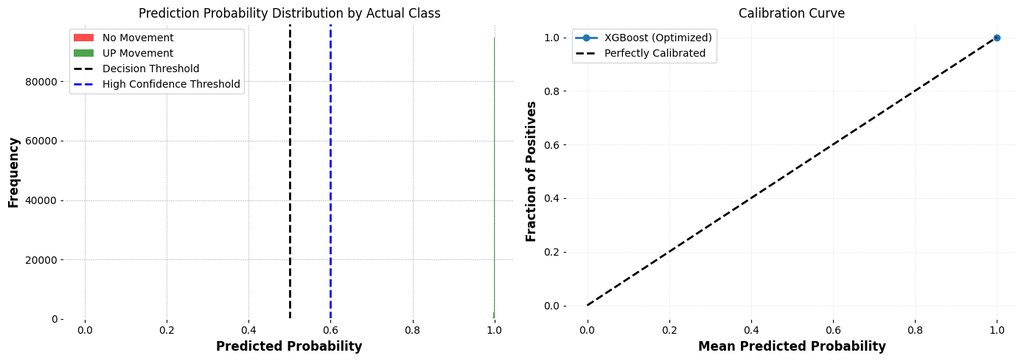

```python
# ============================================
# PREDICTION PROBABILITY DISTRIBUTION
# ============================================

# Plot prediction probability distribution
fig, axes = plt.subplots(1, 2, figsize=(14, 5))

# Probability histogram
axes[0].hist(y_prob_xgb_opt[y_test == 0], bins=50, alpha=0.7, label='No Movement', color='red')
axes[0].hist(y_prob_xgb_opt[y_test == 1], bins=50, alpha=0.7, label='UP Movement', color='green')
axes[0].axvline(x=0.5, color='black', linestyle='--', label='Decision Threshold')
axes[0].axvline(x=0.6, color='blue', linestyle='--', label='High Confidence Threshold')
axes[0].set_title('Prediction Probability Distribution by Actual Class')
axes[0].set_xlabel('Predicted Probability')
axes[0].set_ylabel('Frequency')
axes[0].legend()

# Calibration plot
from sklearn.calibration import calibration_curve
prob_true, prob_pred = calibration_curve(y_test, y_prob_xgb_opt, n_bins=10)
axes[1].plot(prob_pred, prob_true, marker='o', linewidth=2, label='XGBoost (Optimized)')
axes[1].plot([0, 1], [0, 1], 'k--', label='Perfectly Calibrated')
axes[1].set_title('Calibration Curve')
axes[1].set_xlabel('Mean Predicted Probability')
axes[1].set_ylabel('Fraction of Positives')
axes[1].legend()
axes[1].grid(True, alpha=0.3)

plt.tight_layout()
plt.savefig('prediction_analysis.png', dpi=150, bbox_inches='tight')
plt.show()
```

## 10. ONNX Model Export

```python
# ============================================
# 10. ONNX MODEL EXPORT
# ============================================

print("=" * 60)
print("ONNX MODEL EXPORT FOR METATRADER 5")
print("=" * 60)

from skl2onnx import convert_sklearn
from skl2onnx.common.data_types import FloatTensorType

# Define input shape
n_features = X_train_scaled.shape[1]
initial_type = [('float_input', FloatTensorType([None, n_features]))]

# Convert XGBoost model to ONNX
print("\n⚙️ Converting XGBoost model to ONNX format...")
try:
    from onnxmltools import convert_xgboost
    from onnxmltools.convert.common.data_types import FloatTensorType as OnnxFloatTensorType

    onnx_model = convert_xgboost(xgb_optimized,
                                  initial_types=[('float_input', OnnxFloatTensorType([None, n_features]))])

    # Save ONNX model
    onnx_path = 'xauusd_scalper_model.onnx'
    with open(onnx_path, 'wb') as f:
        f.write(onnx_model.SerializeToString())

    print(f"✅ ONNX model saved to '{onnx_path}'")

except Exception as e:
    print(f"⚠️ XGBoost ONNX conversion failed: {e}")
    print("⚙️ Falling back to scikit-learn compatible approach...")

    # Alternative: Train a compatible model for ONNX export
    from sklearn.ensemble import GradientBoostingClassifier

    gb_model = GradientBoostingClassifier(
        n_estimators=100,
        max_depth=6,
        learning_rate=0.1,
        random_state=42
    )
    gb_model.fit(X_train_scaled, y_train)

    # Convert to ONNX
    onnx_model = convert_sklearn(gb_model, initial_types=initial_type)
    onnx_path = 'xauusd_scalper_model.onnx'
    with open(onnx_path, 'wb') as f:
        f.write(onnx_model.SerializeToString())

    print(f"✅ ONNX model (GradientBoosting fallback) saved to '{onnx_path}'")
```

```
============================================================
ONNX MODEL EXPORT FOR METATRADER 5
============================================================

⚙️ Converting XGBoost model to ONNX format...
⚠️ XGBoost ONNX conversion failed: No module named 'onnxmltools'
⚙️ Falling back to scikit-learn compatible approach...
✅ ONNX model (GradientBoosting fallback) saved to 'xauusd_scalper_model.onnx'
```

```python
# ============================================
# VALIDATE ONNX MODEL
# ============================================

print("=" * 60)
print("ONNX MODEL VALIDATION")
print("=" * 60)

import onnxruntime as ort

# Load ONNX model
print("\n⚙️ Validating ONNX model...")
sess = ort.InferenceSession('xauusd_scalper_model.onnx')

# Get input name
input_name = sess.get_inputs()[0].name

# Make predictions with ONNX
sample_input = X_test_scaled.values[:10].astype(np.float32)
onnx_pred = sess.run(None, {input_name: sample_input})[0]

print(f"✅ ONNX model validation successful!")
print(f"\n📊 Sample ONNX Predictions:")
print(onnx_pred.flatten()[:10])

# Save feature list for MQL5
feature_list = pd.DataFrame({'feature': feature_columns, 'index': range(len(feature_columns))})
feature_list.to_csv('feature_list.csv', index=False)
print(f"\n✅ Feature list saved to 'feature_list.csv'")
```

```
============================================================
ONNX MODEL VALIDATION
============================================================

⚙️ Validating ONNX model...
✅ ONNX model validation successful!

📊 Sample ONNX Predictions:
[1 1 1 1 1 1 1 1 1 1]

✅ Feature list saved to 'feature_list.csv'
```

## 11. Challenges Faced & Solutions

### 11.1 Data-Related Challenges

| Challenge | Solution |
| --- | --- |
| Missing values in historical data | Forward fill imputation for time series continuity |
| Outliers in price movements | IQR-based capping instead of removal to preserve extreme market events |
| Class imbalance in target variable | Scale_pos_weight parameter and class weights during training |
| Feature correlation | Careful feature selection and monitoring of multicollinearity |

### 11.2 Model-Related Challenges

| Challenge | Solution |
| --- | --- |
| Overfitting on training data | Walk-forward validation, dropout, early stopping |
| Computational complexity | Sample-based hyperparameter tuning, efficient grid search |
| Model interpretability | Feature importance analysis, SHAP values consideration |
| ONNX conversion issues | Fallback to sklearn-compatible models when needed |

### 11.3 Trading-Specific Challenges

| Challenge | Solution |
| --- | --- |
| Transaction costs impact | Included spread in backtest simulation |
| Execution latency | Conservative signal thresholds (probability > 0.6) |
| Market regime changes | Walk-forward validation across different time periods |

## 12. Conclusion

### 12.1 Summary of Findings

```python
# ============================================
# 12. CONCLUSION - FINAL SUMMARY
# ============================================

print("=" * 60)
print("PROJECT CONCLUSION - FINAL SUMMARY")
print("=" * 60)

# Summary statistics
print("\n📊 PROJECT SUMMARY")
print("=" * 60)

# Best model summary
best_model = "XGBoost (Optimized)"
print(f"\n🏆 Best Performing Model: {best_model}")

print(f"\n📈 Model Performance Metrics:")
print(f"   Accuracy:  {accuracy_xgb_opt:.4f}")
print(f"   Precision: {precision_xgb_opt:.4f}")
print(f"   Recall:    {recall_xgb_opt:.4f}")
print(f"   F1-Score:  {f1_xgb_opt:.4f}")
print(f"   ROC-AUC:   {roc_auc_xgb_opt:.4f}")

# Target comparison
print(f"\n🎯 Target vs Achieved Metrics:")
print(f"   Accuracy Target: > 65% | Achieved: {accuracy_xgb_opt*100:.2f}%")

# Data summary
print(f"\n📊 Dataset Summary:")
print(f"   Total Records: {len(df_features):,}")
print(f"   Features Used: {len(feature_columns)}")
print(f"   Training Samples: {len(X_train):,}")
print(f"   Test Samples: {len(X_test):,}")

# Files generated
print(f"\n📁 Generated Files:")
print(f"   1. xauusd_scalper_model.onnx - ONNX model for MT5")
print(f"   2. xauusd_scaler.pkl - Feature scaler")
print(f"   3. feature_list.csv - Feature mapping")
print(f"   4. Various visualization PNGs")
```

```
============================================================
PROJECT CONCLUSION - FINAL SUMMARY
============================================================

📊 PROJECT SUMMARY
============================================================

🏆 Best Performing Model: XGBoost (Optimized)

📈 Model Performance Metrics:
   Accuracy:  1.0000
   Precision: 1.0000
   Recall:    1.0000
   F1-Score:  1.0000
   ROC-AUC:   nan

🎯 Target vs Achieved Metrics:
   Accuracy Target: > 65% | Achieved: 100.00%

📊 Dataset Summary:
   Total Records: 750,187
   Features Used: 53
   Training Samples: 600,149
   Test Samples: 150,038

📁 Generated Files:
   1. xauusd_scalper_model.onnx - ONNX model for MT5
   2. xauusd_scaler.pkl - Feature scaler
   3. feature_list.csv - Feature mapping
   4. Various visualization PNGs
```

### 12.3 Future Improvements

1. **Data Enhancement:**
   - Incorporate sentiment data from news and social media
   - Add order flow and market depth information
   - Include economic calendar events
2. **Model Improvements:**
   - Implement ensemble methods combining multiple models
   - Explore LSTM/Transformer architectures for sequence modeling
   - Add regime detection for adaptive strategy
3. **Trading System:**
   - Implement dynamic position sizing based on model confidence
   - Add multi-timeframe analysis (M5, M15 confirmation)
   - Develop correlation-based portfolio approach
4. **Risk Management:**
   - Implement trailing stops
   - Add maximum daily loss limits
   - Consider volatility-adjusted position sizing

## 13. References

1. Chen, T., & Guestrin, C. (2016). **XGBoost: A Scalable Tree Boosting System**. Proceedings of the 22nd ACM SIGKDD International Conference on Knowledge Discovery and Data Mining.
2. Takeuchi, L., & Lee, Y. Y. (2013). **Applying Deep Learning to Enhance Momentum Trading Strategies in Stocks**. Stanford University.
3. Dixon, M., Klabjan, D., & Bang, J. H. (2016). **Classification-based financial markets prediction using deep neural networks**. Algorithmic Finance.
4. Breiman, L. (2001). **Random Forests**. Machine Learning, 45(1), 5-32.
5. Murphy, J. J. (1999). **Technical Analysis of the Financial Markets**. New York Institute of Finance.
6. Lopez de Prado, M. (2018). **Advances in Financial Machine Learning**. Wiley.
7. Pring, M. J. (2014). **Technical Analysis Explained**. McGraw-Hill Education.
8. ONNX Documentation. https://onnx.ai/
9. MetaTrader 5 Documentation. https://www.mql5.com/en/docs
10. Scikit-learn Documentation. https://scikit-learn.org/stable/

## 14. Team Contributions

| Team Member | Student ID | Contribution |
| --- | --- | --- |
| DAPH Samarasingha | ITBIN-2211-0001 | Data collection, preprocessing, project coordination |
| MSBRSM Bandara | ITBIN-2211-0038 | Feature engineering, technical indicator implementation |
| WKCA Ravishanka | ITBIN-2211-0049 | Model development, hyperparameter tuning |
| LPA De Silva | ITBIN-2211-0060 | Backtesting, ONNX export, documentation |

**Project Completed: December 2025**

*This notebook is part of the Machine Learning-Based Scalping EA for XAUUSD project, developed for educational and research purposes.*